# Spline model for division rate

Sangwon Hyun and Kristof Glauninger and Francois Ribalet (and others)

# Visualize data

First, we make a visualization of the seaflow data, from the file `data/SeaFlow_SizeDist_regrid-15-5.nc` in the github repository https://github.com/fribalet/Bayesian-matrixmodel .

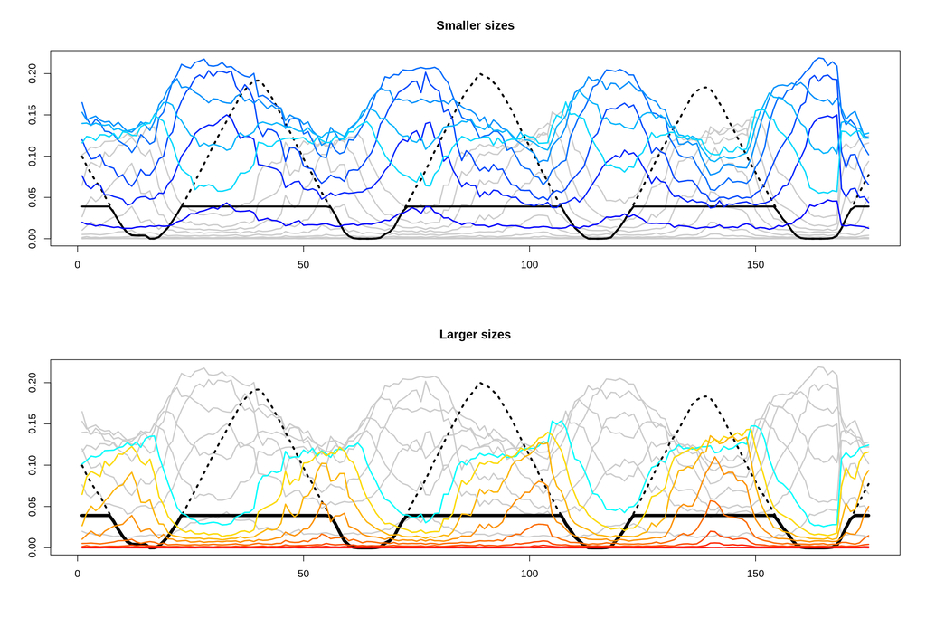

```r
## Setup
ndays            <- 4.0
limit_to_numdays <- 4.0
stride_t_obs     <- 10
data             <- list()
data$dt          <- 10
source(file.path('data_processing.r'))

## Visualize the data
ncat = nrow(data$obs)
cols = colorRamps::blue2red(ncat)
ylim = range(data$obs)

## Make two plots:
par(mfrow=c(2,1))
par = windowsmooth(data$PAR,  ncol(data$obs))

## Smaller sizes
iis=1:7
matplot(t(data$obs), type='l', lwd=2, lty=1, ylim=ylim, col='grey80',
        ylab="")
lines(par/max(par) * 0.2, lwd=3, lty=3)
cutoff = quantile(par/max(par), 0.2)
lines(pmin(par/max(par) * 0.2, cutoff), lwd=3, lty=1)
matlines(t(data$obs)[,iis], type='l', lwd=2, col=cols[iis], lty=1, ylim=ylim)
title(main="Smaller sizes")

## Larger sizes
iis=8:15
matplot(t(data$obs), type='l', lwd=2, col='grey80', lty=1, ylim=ylim,
        main="Larger sizes", ylab="")
lines(par/max(par) * 0.2, lwd=3, lty=3)
cutoff = quantile(par/max(par), 0.2)
lines(pmin(par/max(par) * 0.2, cutoff), lwd=5, lty=1)
matlines(t(data$obs)[,iis], type='l', lwd=2, col=cols[iis], lty=1, ylim=ylim)
```

We can see that the

1. Small size distributions negatively correlate with the large size distributions,
2. Their diel cycles are clearly visible,
3. The small size distributions increase over night (because division is prominent), and
4. The large size distributions increase with a slight lag to the sunlight cycle.

# Spline model for division rate

Recall from the workshop [slides](https://github.com/jpmattern/bayesian_cbiomes/blob/master/lecture_materials/paul/matrixpop.pdf):

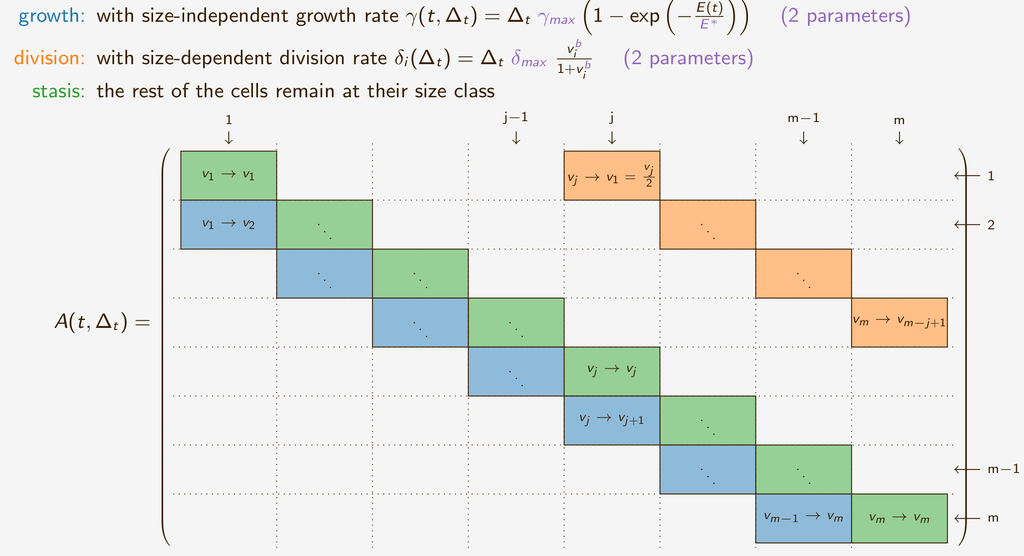

that one idea for modeling the division rate is as follows:

$$\delta_{i}\left(\Delta_{t}\right)=\Delta_{t} \delta_{\max } \frac{v_{i}^{b}}{1+v_{i}^{b}}$$

An alternative idea is that $\{\delta_i\}_{i=1}^{15}$ are all separate parameters, not bound by a parametric form.

My proposal: the division rate vector $\delta \in \mathbb{R}^{15}$ is a sum of $J$ basis vectors:

$$\delta (\Delta_t) = \Delta_t \cdot \sum_{j=1}^J \alpha_j b_j$$

where $b_j$ are spline bases in $\mathbb{R}^n$. The $J$ spline coefficients $\{\alpha_j \in \mathbb{R}\}_{j=1,\cdots,J}$ are new model parameters to estimate.

# What are spline bases and how to use them?

Spline bases are *piecewise* polynomials in the domain of the data ($i=1$ to $15$, or at $\{v_i\}_{i=1,\cdots, 15}$).

In our case, the number of bases $J$ governs the smoothness.

The $J$ spline coefficients $\alpha_j$ are estimated in the model in the usual way e.g. it is given a set of Gaussian priors. Two ends of the spectrum

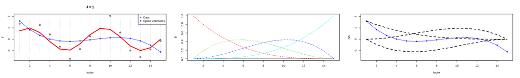

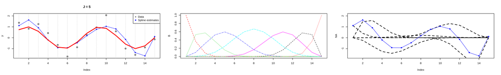

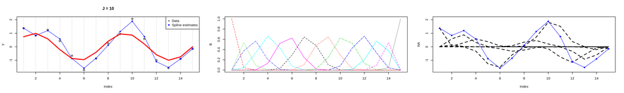

```r
n = 15
set.seed(0)
mn = sin((1:n)/(0.5*n) * 2 * pi)
y = mn + rnorm(n, 0, 0.5)

for(J in c(1,5,10)){
par(mfrow=c(1,3))

## Equally spaced knots
B <- bs(1:n,
        knots = seq(from=1, to=n, length=J),
        degree = 3, intercept = TRUE)

## par(cex=2)
plot(y, pch=16, cex=1.5, col='grey50')
title(main=paste0("J = ", J))
g = lm(y~B-1)
lines(g$fitted, pch=16, col='blue', type='o')
abline(v=1:n, col='grey', lwd=1, lty=3)
## lines(out, type='o', lwd=2, pch=15, cex=1)
lines(mn, lwd=3, col='red')
legend("topright", col=c('grey50', 'blue'), pch=16, legend=c("Data","Spline estimates"))

## Plot the spline bases
matplot(B, type='l')

## Plot the fitted values of each basis
cc = coef(g)
plot(NA, xlim=c(1,n),ylim=range(y))##c(0,max(y)))
for(ii in 1:(J+3)){
  lines(B[,ii] * cc[ii], lty=2, lwd=2)
}
abline(h=cc[1], lty=2, lwd=2)
lines(g$fitted, pch=16, col='blue', type='o')
}
```

# Why use splines?

1. Smoothness in the estimated division rate across size classes fits scientific intuition.
2. Instead of an artificial restriction of the division rate vector to a parametric form (e.g. sigmoidal shaped vectors) without a clear scientific reason to do so, let’s let the data speak.
3. The current model ideas make the division rate vector a function of $v^{\text{left}}_i$. This is left-hand-side limit of each size class. Instead, we can make the division rate be a smooth function of $v^{\text{mid}}_i$, which is the middle of the size class $v^{\text{mid}}_iv^{\text{left}}_i + v^{\text{left}}_{i+1}$.

How to achieve this in stan? Something like this:

```
transformed parameters {
    matrix[m,nt_obs] mod_obspos;
    {
        // helper variables
        vector[m] w_curr;
        vector[m] w_next;
        real delta_i = 0.0;
        real gamma;
        real a;
        real tmp;
        int ito = 1;

        // Justin's addition
        real a0;
        vector[m] a1;

        w_curr = w_ini;

        for (it in 1:nt){ // time-stepping loop
            // record current solution
            if (it == it_obs[ito]){
                mod_obspos[,ito] = w_curr;
                ito += 1;
                if (ito > nt_obs){
                    break;
                }
            }
            // compute gamma
            gamma = gamma_max * dt_days * (1.0 - exp(-E[it]/E_star));


            // Justin's addition: Estimate delta once, as a function of v (or just i)
            /* Remember: define delta, a0, a above */
            delta = to_vector(a0 + a1 * B)

            w_next = rep_vector(0.0, m);
            for (i in 1:m){ // size-class loop
                // compute delta_i
                delta_i = delta[i]

                // fill subdiagonal (growth)
                if (i < j){
                    //A[i+1,i] = gamma;
                    a = gamma;
                    w_next[i+1] += a * w_curr[i];
                } else if (i < m){
                    //A[i+1,i] = gamma * (1.0-delta_i);
                    a = gamma * (1.0-delta_i);
                    w_next[i+1] += a * w_curr[i];
                }
                // fill (j-1)th superdiagonal (division)
                if (i >= j){
                    //A[i+1-j,i] = 2.0*delta_i;
                    a = 2.0*delta_i;
                    w_next[i+1-j] += a * w_curr[i];
                }
```

# Extensions

## Tune $J$

(This is not important for now – we should just use a fixed reasonably small $J$.)

The choice of $J$ (locations and number of the knots) described thus far are arbitrary. This is fine for now, but a more *principled* way is to starting with a much larger set of spline bases (e.g. large $J$, like $J \simeq n$), then using a smoothing prior on the spline coefficients. The spline bases are the local polynomials, so that when coefficients are close to each other, the resulting vector $\sum_{j=1}^J \alpha_j b_j$ should be smoother.

The prior on the coefficients are something like this:

$$\alpha_{1} \sim \mathcal{N}(0,1) \quad \alpha_{i} \sim
\mathcal{N}\left(\alpha_{i-1}, \tau\right) \quad \tau \sim \mathcal{N}(0,1)$$

and in stan code, it is something like this:

```
transformed parameters {
  row_vector[num_basis] a;
  vector[num_data] Y_hat;
  a[1] = a_raw[1];
  for (i in 2:num_basis)
    a[i] = a[i-1] + a_raw[i]*tau;
  Y_hat = a0*to_vector(X) + to_vector(a*B);
}
```

## Enforce monotonicity

We can enforce monotonicity in the division rate vector artificially in the spline framework as well. We can use an overall linear basis (the one that is basically a scaled version of `seq(from=1, to=n, by=1)`, to always be included with the B spline basis), and make sure the coefficient has a large absolute value.

Other keywords to explore: isotonic trend filtering, isotonic regression.

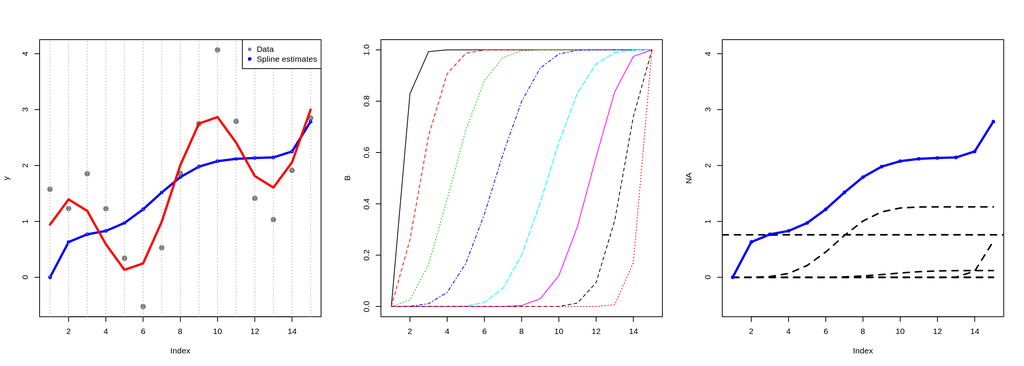

```r
library(splines2)
library(lsei)
n = 15
set.seed(0)
mn = sin((1:n)/(0.5*n) * 2 * pi) + 0.2*(1:n)
y = mn + rnorm(n, 0, 0.5)

J = 8
par(mfrow=c(1,3))
plot(y, pch=16, cex=1.5, col='grey50')
B = iSpline(1:n,
            df = J,
            intercept=TRUE)
u <- nnls(B, y)$x
lines(B%*%u, lwd=3, col='blue', pch=16, type='o')
abline(v=1:n, col='grey', lwd=1, lty=3)
legend("topright", col=c('grey50', 'blue'), pch=16, legend=c("Data","Spline estimates"))
lines(mn, lwd=3, col='red')

## Plot the spline bases
matplot(B, type='l')

## Plot the fitted values of each basis
cc = u
plot(NA, xlim=c(1,n),ylim=range(y))##c(0,max(y)))
for(ii in 1:(J)){
  lines(B[,ii] * cc[ii], lty=2, lwd=2)
}
abline(h=cc[1], lty=2, lwd=2)
lines(B%*%u, lwd=3, col='blue', pch=16, type='o')
```

```r
## lines(u$fitted, pch=16, col='blue', type='o')
```

# References:

1. https://mc-stan.org/users/documentation/case-studies/splines_in_stan.html
2. https://www.dropbox.com/s/lxiefrnu4sgp065/chapter-12?dl=0
3. https://rpubs.com/deleeuw/268327